# Matplotlib

# Set Line Properties for the Grid

You can also set the line properties of the grid, like this: grid(color = 'color', linestyle = 'linestyle', linewidth = number).

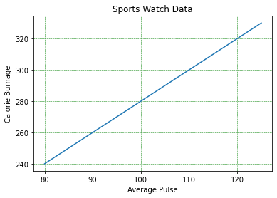

```python
# Set the line properties of the grid:

import numpy as np
import matplotlib.pyplot as plt

x = np.array([80, 85, 90, 95, 100, 105, 110, 115, 120, 125])
y = np.array([240, 250, 260, 270, 280, 290, 300, 310, 320, 330])

plt.title("Sports Watch Data")
plt.xlabel("Average Pulse")
plt.ylabel("Calorie Burnage")

plt.plot(x, y)

plt.grid(color = 'green', linestyle = '--', linewidth = 0.5)

plt.show()
```

# Matplotlib Subplot

### Display Multiple Plots

With the subplot() function you can draw multiple plots in one figure:

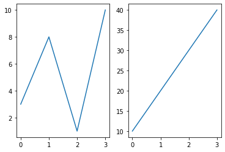

```python
# Draw 2 plots:

import matplotlib.pyplot as plt
import numpy as np

#plot 1:
x = np.array([0, 1, 2, 3])
y = np.array([3, 8, 1, 10])

plt.subplot(1, 2, 1)
plt.plot(x,y)

#plot 2:
x = np.array([0, 1, 2, 3])
y = np.array([10, 20, 30, 40])

plt.subplot(1, 2, 2)
plt.plot(x,y)

plt.show()
```

## The subplot() Function

The subplot() function takes three arguments that describes the layout of the figure.

The layout is organized in rows and columns, which are represented by the first and second argument.

The third argument represents the index of the current plot.

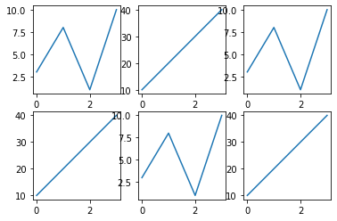

```python
# Draw 6 plots:

import matplotlib.pyplot as plt
import numpy as np

x = np.array([0, 1, 2, 3])
y = np.array([3, 8, 1, 10])

plt.subplot(2, 3, 1)
plt.plot(x,y)

x = np.array([0, 1, 2, 3])
y = np.array([10, 20, 30, 40])

plt.subplot(2, 3, 2)
plt.plot(x,y)

x = np.array([0, 1, 2, 3])
y = np.array([3, 8, 1, 10])

plt.subplot(2, 3, 3)
plt.plot(x,y)

x = np.array([0, 1, 2, 3])
y = np.array([10, 20, 30, 40])

plt.subplot(2, 3, 4)
plt.plot(x,y)

x = np.array([0, 1, 2, 3])
y = np.array([3, 8, 1, 10])

plt.subplot(2, 3, 5)
plt.plot(x,y)

x = np.array([0, 1, 2, 3])
y = np.array([10, 20, 30, 40])

plt.subplot(2, 3, 6)
plt.plot(x,y)

plt.show()
```

## Title

You can add a title to each plot with the title() function:

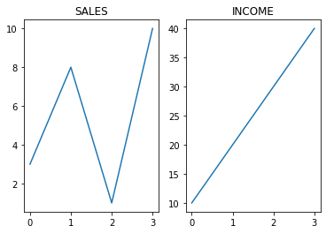

```python
# 2 plots, with titles:

import matplotlib.pyplot as plt
import numpy as np

#plot 1:
x = np.array([0, 1, 2, 3])
y = np.array([3, 8, 1, 10])

plt.subplot(1, 2, 1)
plt.plot(x,y)
plt.title("SALES")

#plot 2:
x = np.array([0, 1, 2, 3])
y = np.array([10, 20, 30, 40])

plt.subplot(1, 2, 2)
plt.plot(x,y)
plt.title("INCOME")

plt.show()
```

### Super Title

You can add a title to the entire figure with the suptitle() function:

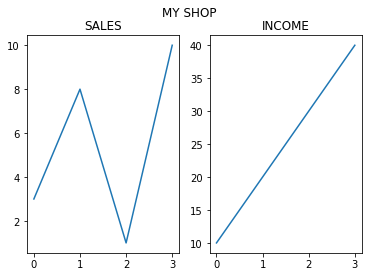

```python
# Add a title for the entire figure:

import matplotlib.pyplot as plt
import numpy as np

#plot 1:
x = np.array([0, 1, 2, 3])
y = np.array([3, 8, 1, 10])

plt.subplot(1, 2, 1)
plt.plot(x,y)
plt.title("SALES")

#plot 2:
x = np.array([0, 1, 2, 3])
y = np.array([10, 20, 30, 40])

plt.subplot(1, 2, 2)
plt.plot(x,y)
plt.title("INCOME")

plt.suptitle("MY SHOP")
plt.show()
```

# Matplotlib Scatter

### Creating Scatter Plots

With Pyplot, you can use the scatter() function to draw a scatter plot.

The scatter() function plots one dot for each observation. It needs two arrays of the same length, one for the values of the x-axis, and one for values on the y-axis:

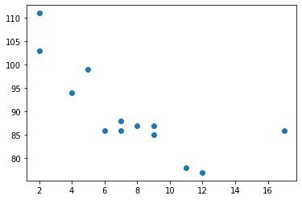

```python
# A simple scatter plot:

import matplotlib.pyplot as plt
import numpy as np

x = np.array([5,7,8,7,2,17,2,9,4,11,12,9,6])
y = np.array([99,86,87,88,111,86,103,87,94,78,77,85,86])

plt.scatter(x, y)
plt.show()
```

## Compare Plots

In the example above, there seems to be a relationship between speed and age, but what if we plot the observations from another day as well? Will the scatter plot tell us something else?

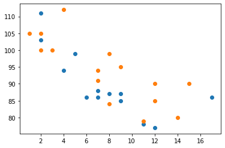

```python
# Draw two plots on the same figure:

import matplotlib.pyplot as plt
import numpy as np

#day one, the age and speed of 13 cars:
x = np.array([5,7,8,7,2,17,2,9,4,11,12,9,6])
y = np.array([99,86,87,88,111,86,103,87,94,78,77,85,86])
plt.scatter(x, y)

#day two, the age and speed of 15 cars:
x = np.array([2,2,8,1,15,8,12,9,7,3,11,4,7,14,12])
y = np.array([100,105,84,105,90,99,90,95,94,100,79,112,91,80,85])
plt.scatter(x, y)

plt.show()
```

# Colors

You can set your own color for each scatter plot with the color or the c argument:

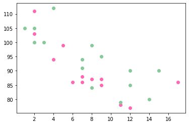

```python
# Set your own color of the markers:

import matplotlib.pyplot as plt
import numpy as np

x = np.array([5,7,8,7,2,17,2,9,4,11,12,9,6])
y = np.array([99,86,87,88,111,86,103,87,94,78,77,85,86])
plt.scatter(x, y, color = 'hotpink')

x = np.array([2,2,8,1,15,8,12,9,7,3,11,4,7,14,12])
y = np.array([100,105,84,105,90,99,90,95,94,100,79,112,91,80,85])
plt.scatter(x, y, color = '#88c999')

plt.show()
```

# Color Each Dot

You can even set a specific color for each dot by using an array of colors as value for the c argument:

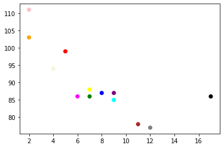

```python
# Set your own color of the markers:

import matplotlib.pyplot as plt
import numpy as np

x = np.array([5,7,8,7,2,17,2,9,4,11,12,9,6])
y = np.array([99,86,87,88,111,86,103,87,94,78,77,85,86])
colors = np.array(["red","green","blue","yellow","pink","black","orange","purple","beige","brown","gray","cyan","magenta"])

plt.scatter(x, y, c=colors)

plt.show()
```

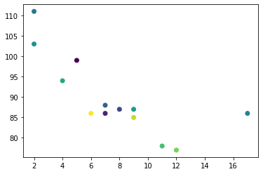

```python
# Create a color array, and specify a colormap in the scatter plot:

import matplotlib.pyplot as plt
import numpy as np

x = np.array([5,7,8,7,2,17,2,9,4,11,12,9,6])
y = np.array([99,86,87,88,111,86,103,87,94,78,77,85,86])
colors = np.array([0, 10, 20, 30, 40, 45, 50, 55, 60, 70, 80, 90, 100])

plt.scatter(x, y, c=colors, cmap='viridis')

plt.show()
```

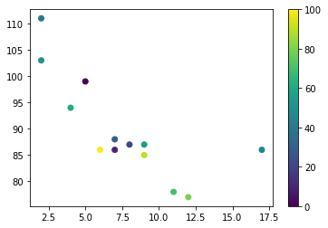

```python
# Include the actual colormap:

import matplotlib.pyplot as plt
import numpy as np

x = np.array([5,7,8,7,2,17,2,9,4,11,12,9,6])
y = np.array([99,86,87,88,111,86,103,87,94,78,77,85,86])
colors = np.array([0, 10, 20, 30, 40, 45, 50, 55, 60, 70, 80, 90, 100])

plt.scatter(x, y, c=colors, cmap='viridis')

plt.colorbar()

plt.show()
```

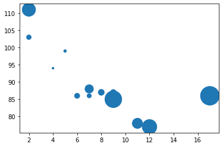

```python
# Set your own size for the markers:

import matplotlib.pyplot as plt
import numpy as np

x = np.array([5,7,8,7,2,17,2,9,4,11,12,9,6])
y = np.array([99,86,87,88,111,86,103,87,94,78,77,85,86])
sizes = np.array([20,50,100,200,500,1000,60,90,10,300,600,800,75])

plt.scatter(x, y, s=sizes)

plt.show()
```

# Alpha

You can adjust the transparency of the dots with the alpha argument.

Just like colors, make sure the array for sizes has the same length as the arrays for the x- and y-axis:

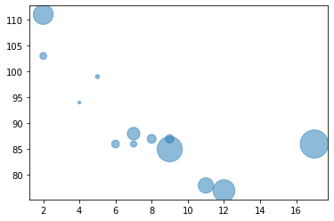

```python
# Set your own size for the markers:

import matplotlib.pyplot as plt
import numpy as np

x = np.array([5,7,8,7,2,17,2,9,4,11,12,9,6])
y = np.array([99,86,87,88,111,86,103,87,94,78,77,85,86])
sizes = np.array([20,50,100,200,500,1000,60,90,10,300,600,800,75])

plt.scatter(x, y, s=sizes, alpha=0.5)

plt.show()
```

### Combine Color Size and Alpha

You can combine a colormap with different sizes of the dots. This is best visualized if the dots are transparent:

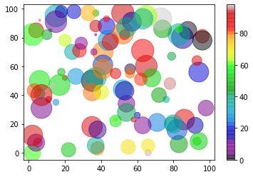

```python
# Create random arrays with 100 values for x-points, y-points, colors and sizes:

import matplotlib.pyplot as plt
import numpy as np

x = np.random.randint(100, size=(100))
y = np.random.randint(100, size=(100))
colors = np.random.randint(100, size=(100))
sizes = 10 * np.random.randint(100, size=(100))

plt.scatter(x, y, c=colors, s=sizes, alpha=0.5, cmap='nipy_spectral')

plt.colorbar()

plt.show()
```

# Creating Bars

With Pyplot, you can use the bar() function to draw bar graphs:

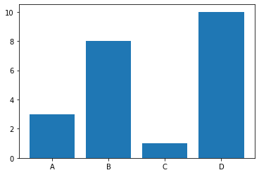

```python
# Draw 4 bars:

import matplotlib.pyplot as plt
import numpy as np

x = np.array(["A", "B", "C", "D"])
y = np.array([3, 8, 1, 10])

plt.bar(x,y)
plt.show()
```

#### The bar() function takes arguments that describes the layout of the bars

```
<BarContainer object of 2 artists>
```

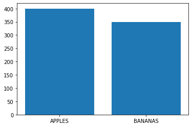

```python
# Example
x = ["APPLES", "BANANAS"]
y = [400, 350]
plt.bar(x, y)
```

### Horizontal Bars

If you want the bars to be displayed horizontally instead of vertically, use the barh() function:

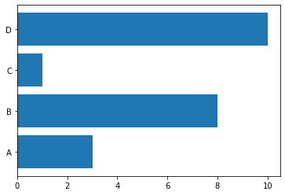

```python
# Draw 4 horizontal bars:

import matplotlib.pyplot as plt
import numpy as np

x = np.array(["A", "B", "C", "D"])
y = np.array([3, 8, 1, 10])

plt.barh(x, y)
plt.show()
```

# Bar Color

The bar() and barh() take the keyword argument color to set the color of the bars:

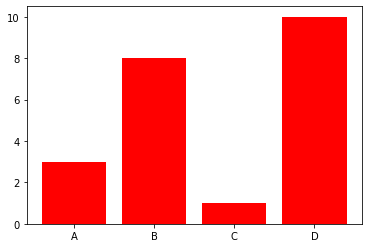

```python
# Draw 4 red bars:

import matplotlib.pyplot as plt
import numpy as np

x = np.array(["A", "B", "C", "D"])
y = np.array([3, 8, 1, 10])

plt.bar(x, y, color = "red")
plt.show()
```

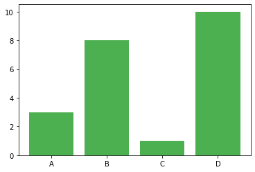

```python
# Draw 4 bars with a beautiful green color:

import matplotlib.pyplot as plt
import numpy as np

x = np.array(["A", "B", "C", "D"])
y = np.array([3, 8, 1, 10])

plt.bar(x, y, color = "#4CAF50")
plt.show()
```

## Bar Width

The bar() takes the keyword argument width to set the width of the bars:

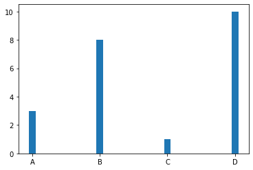

```python
# Draw 4 very thin bars:

import matplotlib.pyplot as plt
import numpy as np

x = np.array(["A", "B", "C", "D"])
y = np.array([3, 8, 1, 10])

plt.bar(x, y, width = 0.1)
plt.show()
```

## Bar Height

The barh() takes the keyword argument height to set the height of the bars:

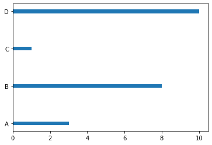

```python
# Draw 4 very thin bars:

import matplotlib.pyplot as plt
import numpy as np

x = np.array(["A", "B", "C", "D"])
y = np.array([3, 8, 1, 10])

plt.barh(x, y, height = 0.1)
plt.show()
```

# Matplotlib Histograms

## Histogram

A histogram is a graph showing frequency distributions.

It is a graph showing the number of observations within each given interval.

### Create Histogram

In Matplotlib, we use the hist() function to create histograms.

The hist() function will use an array of numbers to create a histogram, the array is sent into the function as an argument.

```python
# A Normal Data Distribution by NumPy:

import numpy as np

x = np.random.normal(170, 10, 250)

print(x)
```

```
[166.78713639 181.65372115 176.11672652 171.84803635 184.79898189
 164.59001215 163.11269268 175.07986515 178.10238112 181.51253613
 169.97731221 164.10137259 166.81258189 166.26400062 153.65667265
 181.83841227 180.09226505 153.28485472 169.8672089  164.74764242
 169.05444084 174.75786067 189.7247799  167.6846811  173.06783905
 176.78197016 175.99643648 170.17411467 187.18137852 156.98912273
 168.74026925 150.71991465 179.24622635 160.1648258  161.41015333
 178.38025927 177.82122438 185.9043328  165.36678512 171.59019318
 165.45016813 166.0358254  167.66867173 169.19116885 165.68510133
 152.96792122 183.52215319 183.88273786 151.84440274 192.60870967
 181.70119613 179.31888988 187.96858793 173.09908405 171.7416845
 176.0152846  175.53300857 159.37228006 179.71000021 167.58073331
 186.75678482 161.54513387 182.84669031 177.50280643 178.81085643
 158.77300092 177.27449397 179.68193888 153.36054006 163.98854965
 166.55004316 170.49805318 161.53947222 149.89575007 171.69454617
 176.13171035 171.33569804 168.14443692 177.86599619 174.46155677
 178.08916732 154.00414427 177.60794825 167.36359492 185.94632596
 177.5165365  159.07187644 155.05236153 165.68402293 190.33944543
 162.69492234 155.21133336 167.60695358 155.71059172 160.6331757
 170.50756635 173.89918789 167.76187102 180.3231077  171.10355136
 166.81102102 165.8300126  169.99439432 177.61144078 173.2374687
 172.56529817 172.73344848 164.7856089  164.11325774 167.12824915
 160.2156104  165.78499941 174.62384398 178.07249596 165.91863148
 147.32725741 161.66027651 168.36997619 176.92229566 163.94964834
 186.36340126 161.7943983  158.76161583 188.91908503 182.18108961
 169.74894911 151.22155141 164.31482245 161.71782911 147.54374821
 178.68167793 171.86418897 173.60687295 155.11880036 166.94521144
 167.00783724 172.43682012 154.6329739  161.60855258 184.90443006
 183.24797875 180.48477031 177.67987817 156.35825734 175.51849086
 170.25629804 182.96367094 172.83330367 171.69399238 167.93924165
 165.81071233 171.54277255 173.76561246 172.81412097 160.94705839
 170.94324448 168.52644376 158.04513305 176.39995677 160.6197392
 186.67284849 176.45402278 164.30913337 173.29956129 169.01935044
 166.13885448 166.55747687 174.17145518 171.84887077 165.63358791
 169.96183074 166.54375246 172.84479171 168.9550548  175.85643915
 185.28368902 147.02738584 161.00910053 178.88824447 165.28814784
 159.28308891 161.33860773 182.09107743 166.50079099 143.37210165
 153.02145372 164.10016941 159.96063625 176.57199086 178.76813985
 169.37077859 172.02785201 168.11104319 161.09944722 157.84135813
 156.81749382 158.23204992 156.99268809 158.85950325 170.44559039
 158.41496448 164.9093122  173.93926751 180.1648748  176.22536954
 160.50454435 150.8220035  172.82981523 176.45490792 155.16467941
 151.72674147 181.21510791 158.48793701 178.03126122 165.36153424
 168.81324688 166.38260474 173.05117499 161.76064998 180.62416841
 176.9134368  166.65756238 180.01920239 173.3457366  172.88363135
 155.47620701 154.33532309 171.21401427 167.54692493 177.43278289
 163.90752625 169.85976212 162.81666699 162.60212587 164.32890447
 158.71763002 185.92672112 169.21113968 172.12595076 171.85400011
 166.51721558 160.72267383 183.38207925 180.59025838 159.93752835
 177.43847369 158.91939337 162.05635276 167.1404957  177.27892542]
```

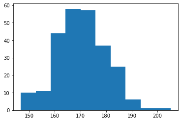

```python
# A simple histogram:

import matplotlib.pyplot as plt
import numpy as np

x = np.random.normal(170, 10, 250)

plt.hist(x)
plt.show()
```

# Matplotlib Pie Charts

### Creating Pie Charts

With Pyplot, you can use the pie() function to draw pie charts:

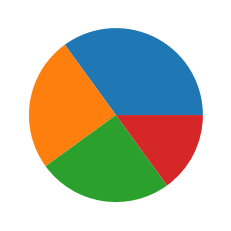

```python
## A simple pie chart:

import matplotlib.pyplot as plt
import numpy as np

y = np.array([35, 25, 25, 15])

plt.pie(y)
plt.show()
```

### Labels

The label parameter must be an array with one label for each wedge:

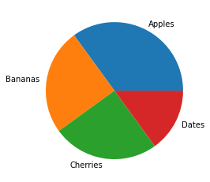

```python
# A simple pie chart:

import matplotlib.pyplot as plt
import numpy as np

y = np.array([35, 25, 25, 15])
mylabels = ["Apples", "Bananas", "Cherries", "Dates"]

plt.pie(y, labels = mylabels)
plt.show()
```

## Start Angle

The startangle parameter is defined with an angle in degrees, default angle is 0:

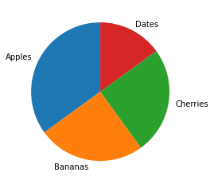

```python
# Start the first wedge at 90 degrees:

import matplotlib.pyplot as plt
import numpy as np

y = np.array([35, 25, 25, 15])
mylabels = ["Apples", "Bananas", "Cherries", "Dates"]

plt.pie(y, labels = mylabels, startangle = 90)
plt.show()
```

# Explode

Maybe you want one of the wedges to stand out? The explode parameter allows you to do that.

The explode parameter, if specified, and not None, must be an array with one value for each wedge.

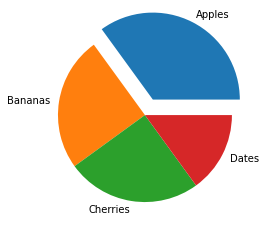

```python
# Pull the "Apples" wedge 0.2 from the center of the pie:

import matplotlib.pyplot as plt
import numpy as np

y = np.array([35, 25, 25, 15])
mylabels = ["Apples", "Bananas", "Cherries", "Dates"]
myexplode = [0.2, 0, 0, 0]

plt.pie(y, labels = mylabels, explode = myexplode)
plt.show()
```

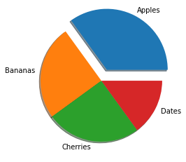

```python
# Add a shadow:

import matplotlib.pyplot as plt
import numpy as np

y = np.array([35, 25, 25, 15])
mylabels = ["Apples", "Bananas", "Cherries", "Dates"]
myexplode = [0.2, 0, 0, 0]

plt.pie(y, labels = mylabels, explode = myexplode, shadow = True)
plt.show()
```

### Colors

You can set the color of each wedge with the colors parameter.

The colors parameter, if specified, must be an array with one value for each wedge:

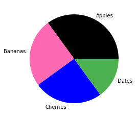

```python
# Specify a new color for each wedge:

import matplotlib.pyplot as plt
import numpy as np

y = np.array([35, 25, 25, 15])
mylabels = ["Apples", "Bananas", "Cherries", "Dates"]
mycolors = ["black", "hotpink", "b", "#4CAF50"]

plt.pie(y, labels = mylabels, colors = mycolors)
plt.show()
```

'r' - Red 'g' - Green 'b' - Blue 'c' - Cyan 'm' - Magenta 'y' - Yellow 'k' - Black 'w' - White

### Legend

To add a list of explanation for each wedge, use the legend() function:

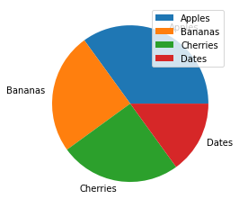

```python
## Add a legend:

import matplotlib.pyplot as plt
import numpy as np

y = np.array([35, 25, 25, 15])
mylabels = ["Apples", "Bananas", "Cherries", "Dates"]

plt.pie(y, labels = mylabels)
plt.legend()
plt.show()
```

# Legend With Header

To add a header to the legend, add the title parameter to the legend function.

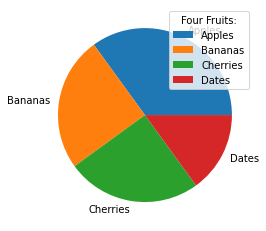

```python
# Add a legend with a header:

import matplotlib.pyplot as plt
import numpy as np

y = np.array([35, 25, 25, 15])
mylabels = ["Apples", "Bananas", "Cherries", "Dates"]

plt.pie(y, labels = mylabels)
plt.legend(title = "Four Fruits:")
plt.show()
```